# Power.Analysis.1yr

Alene Onion

April 4, 2019

## Introduction

This document was prepare to analyze the number of samples necessary to determine that a lake has an average phosphorus value above or below the threshold of 20 ug/L.

We use a one tailed t test, assuming an alpha value of 0.15 as per EPA 2002. The output is power. To be clear, power is the probability that the lake has a TP value above or below the standard threshold of 20 ug/L (above was calculated separately than below). According to EPA 2002 an acceptable level of power is 80% or 0.8 in the plots below.

I felt the following graphic helped to understand the power calcuation. In the graphic below, alpha is the hatched tail, Ho is the phosphorus standard (a straight line in our one tailed t test), Ha is the average TP value for the lake, and power is the percent of the lake samples below the alpha/2 value.

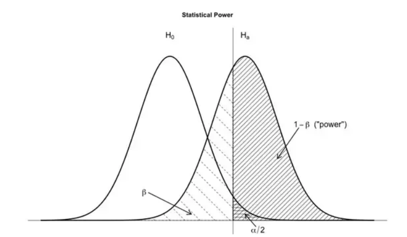

from:https://www.quora.com/What-is-the-relationship-between-statistical-power-and-the-p-value

## Comparing number of years sampling

Not surprisingly, there isn’t much difference between years of sampling compared to number of samples collected. This is because there isn’t much variance from year to year but there is variance between seasons. For this reason, we feel the number of years a lake is samples is less important than the number of samples collected.

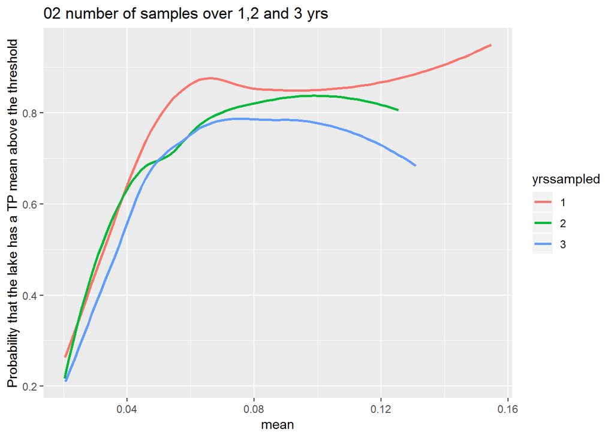

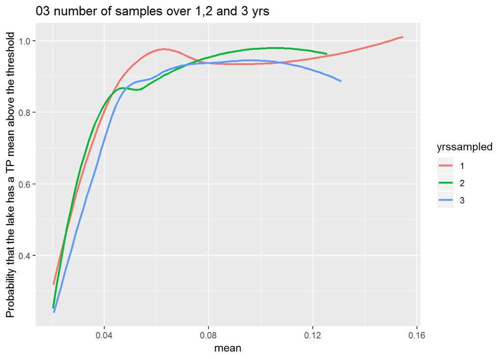

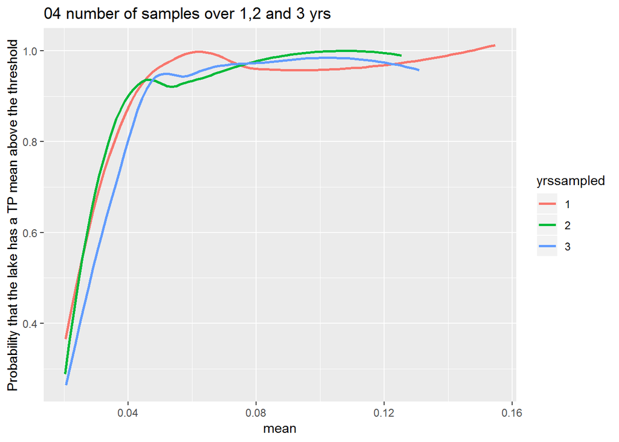

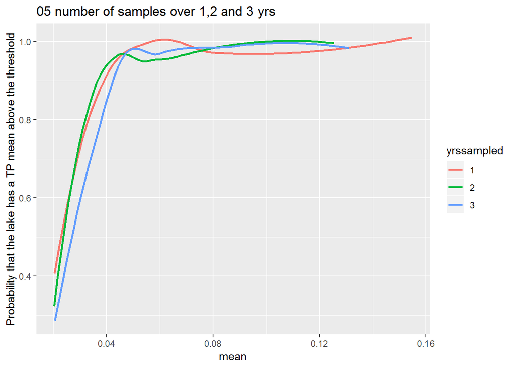

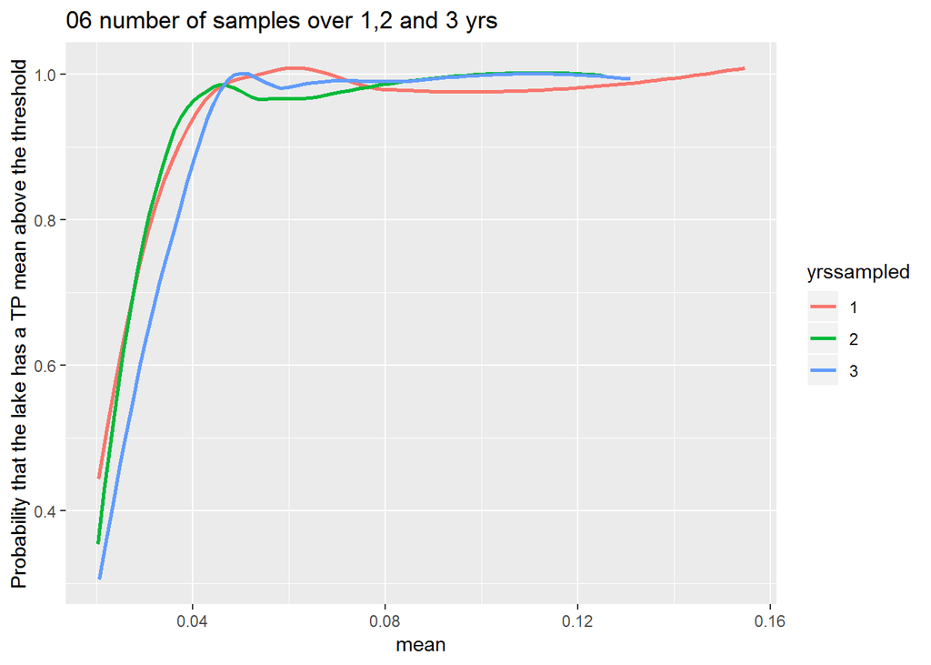

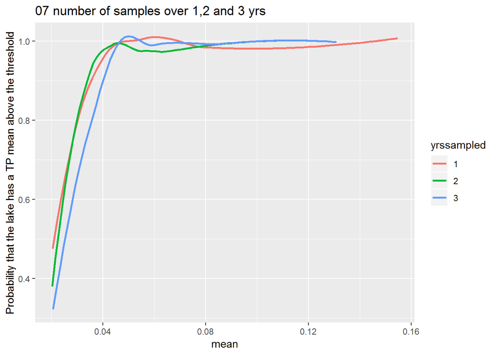

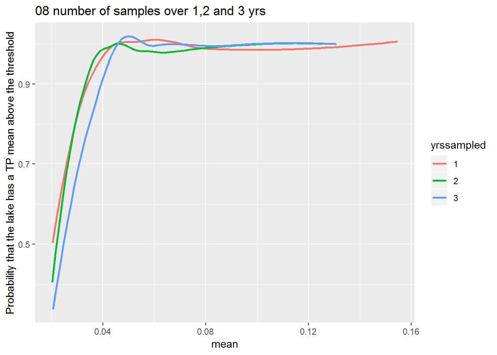

## Comparing sample number

Comparing the power contributed by sampling 2-20 times in lakes existing in our database.  
Because of our conclusions above, we pulled all the lakes with at least one year of sampling. This dramatically increased our test data set (from 51-264). We pulled the most recent year of sampling from each lake and omitted lakes that had less han 4 samples collected in that year.

As a reminder, an acceptable level of power (or probability) is 80% according to EPA 2002. For this reason, we have drawn a horizontal line at 80% probability (0.8) in the plots below.

I feel it’s worth considering the “threatened” category for lakes that fall within this uncertain range.

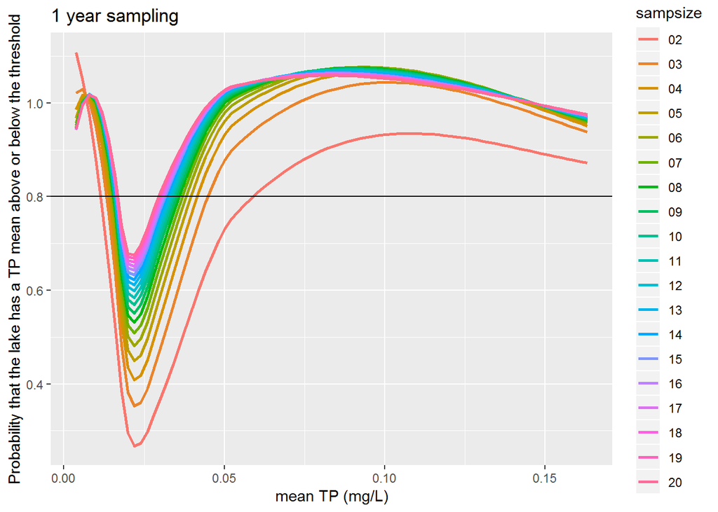

In the plot below, we have only those lakes whose mean is above the TP threshold (20 ug/L).  
From this plot we concluded:

1. Two samples are sufficient to conclude that a lake with a mean of 58ug/L or higher is above the threshold of 20 ug/L.
2. Six samples, as LCI is able to collect over two years, are sufficient to conclude that a lake with a mean of 30 ug/L or higher is above the threshold of 20 ug/L.
3. Twenty or more samples, as CSLAP is easily able to collect over three years, are sufficient to conclude that a lake with a mean of 25 ug/L or higher is above the threshold of 20 ug/L.
4. No ammount of sampling is able to conclude taht a lake with a mean of < 25 ug/L is above the threshold of 20 ug/L.

vertical lines in the plot below:  
x = 0.025  
x = 0.03  
x = 0.058

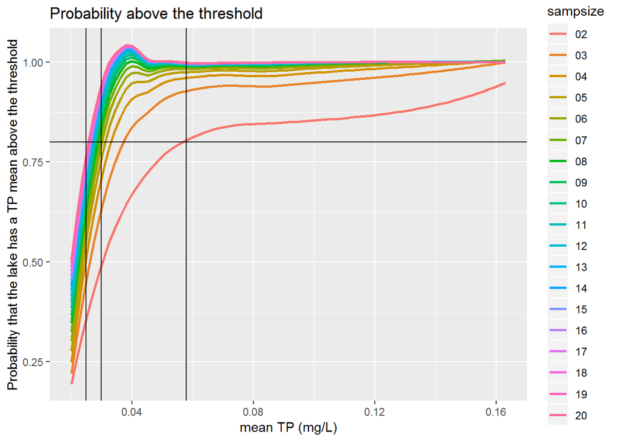

In the plot below, we have only those lakes whose mean is below the TP threshold (20 ug/L).  
From this plot we concluded:

vertical lines in the plot below:  
x = 0.012  
x = 0.0159  
x = 0.01715

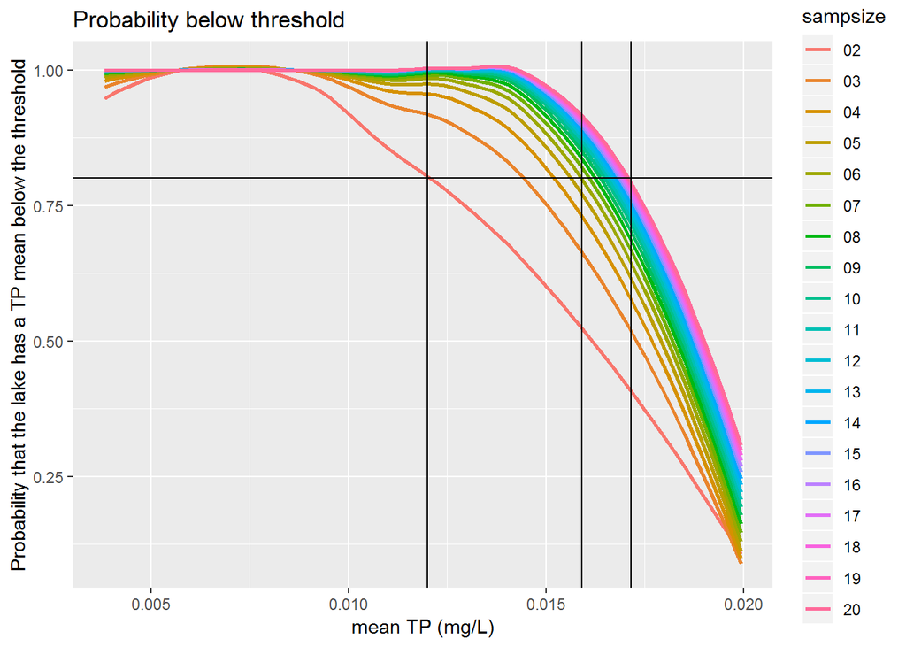

## References

EPA 2002. Consolidated Assessment and Listing Methodology. First Edition. Available at: https://www.epa.gov/sites/production/files/2015-09/documents/consolidated_assessment_and_listing_methodology_calm.pdf